# Lab 4: MATH 4753

# Task 3

- Suppose that there is a bag of 20 marbles, 12 white (“1”) and 8 black “0”. Using the sample() function create a sample of size n = 5 without replacement.

```r
sample(c(1, 1, 1, 1, 1, 1, 1, 1, 1, 1, 1, 1, 0, 0, 0, 0, 0, 0, 0, 0), 5, replace = FALSE, prob = NULL)
```

```
## [1] 0 1 1 1 1
```

- Now do the same with replace = TRUE

```r
sample(c(1, 1, 1, 1, 1, 1, 1, 1, 1, 1, 1, 1, 0, 0, 0, 0, 0, 0, 0, 0), 5, replace = TRUE, prob = NULL)
```

```
## [1] 1 0 1 0 1
```

- Use the function myhyper(), on Canvas, assume Y = number of whites, remember sampling is without replacement, n = 5. Use this code to make barplots of Y for the following number of iterations:
  - 100

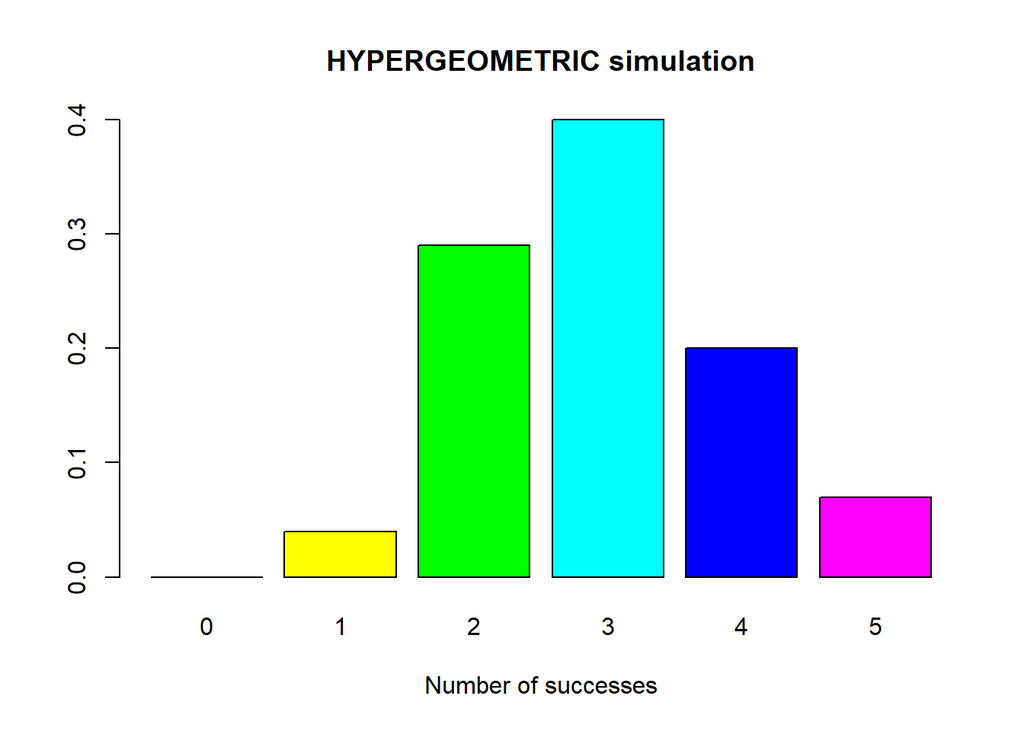

```
##
##    0    1    2    3    4    5
## 0.00 0.04 0.29 0.40 0.20 0.07
```

```r
myhyper(iter=100, n = 5, N = 20, r = 12)
```

- 200

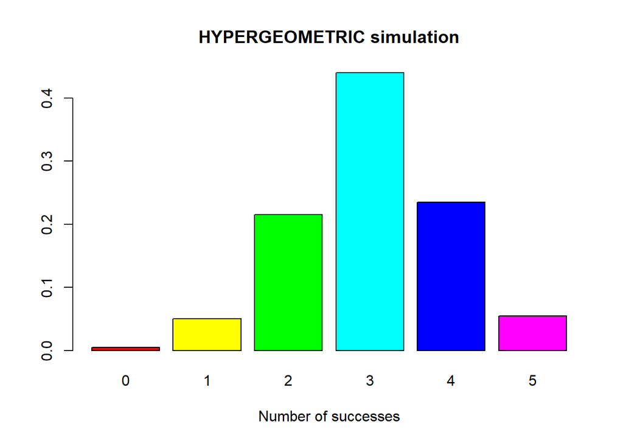

```
##
##     0     1     2     3     4     5
## 0.005 0.050 0.215 0.440 0.235 0.055
```

```r
myhyper(iter=200, n = 5, N = 20, r = 12)
```

- 500

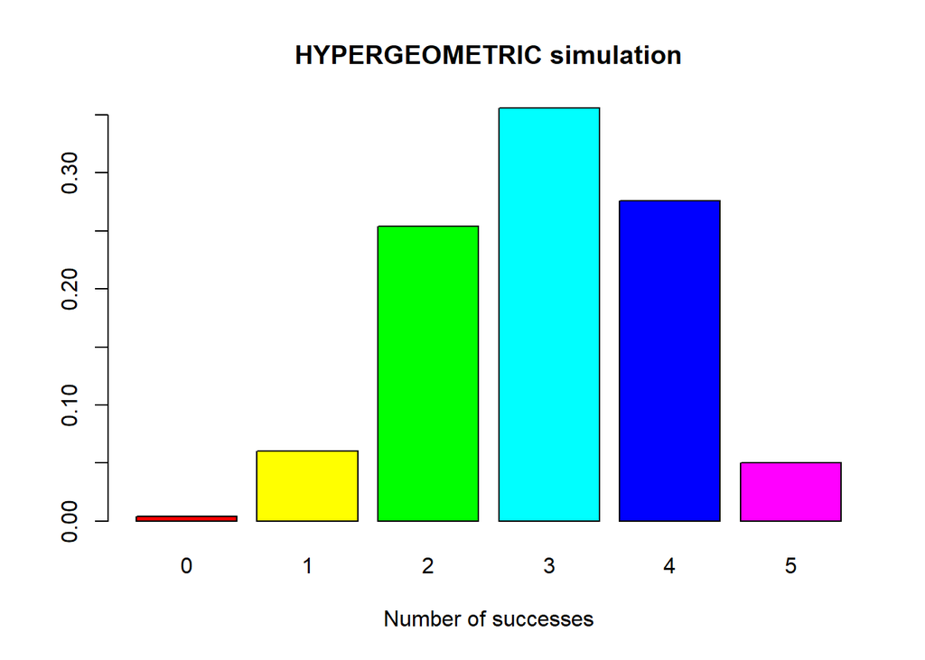

```
##
##     0     1     2     3     4     5
## 0.004 0.060 0.254 0.356 0.276 0.050
```

```r
myhyper(iter=500, n = 5, N = 20, r = 12)
```

- 1000

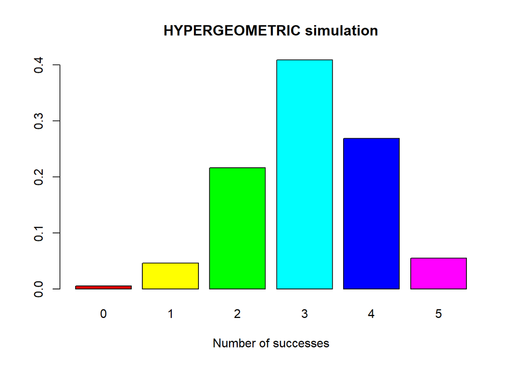

```
##
##     0     1     2     3     4     5
## 0.005 0.046 0.216 0.409 0.269 0.055
```

```r
myhyper(iter=1000, n = 5, N = 20, r = 12)
```

- 10,000

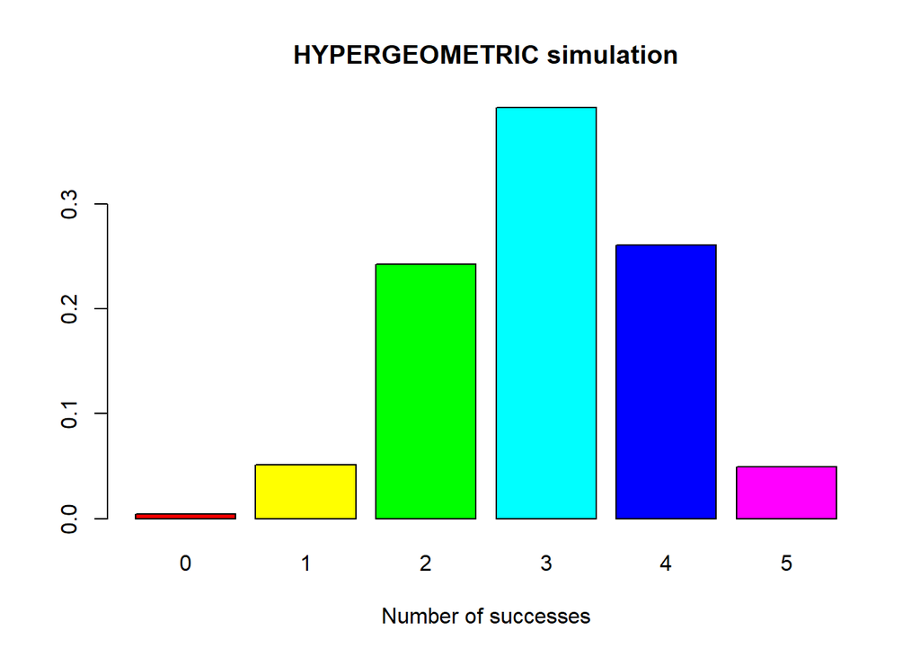

```
##
##      0      1      2      3      4      5
## 0.0041 0.0512 0.2426 0.3919 0.2607 0.0495
```

```r
myhyper(iter=10000, n = 5, N = 20, r = 12)
```

- For the last simulation (10,000 iterations), copy and paste the table that is produced from the function.

See the final table output above.

- Verify that each value in the table is approximately correct using dhyper().

```r
round(dhyper(x=0:5, m=12, n=8, k=5), 4)
```

```
## [1] 0.0036 0.0542 0.2384 0.3973 0.2554 0.0511
```

We can see that these values are very close to the table given from the myhyper() function.

# Task 4

- In lab5.r there is a function called mysample(). Look at the code and describewhat you think it should do and record your response here.

After a brief look at the function, it seems like random samples and the corresponding bar plots are being created, and the number of samples taken depends on how many iterations are given. Once the bar plot is created, R will put it in the console after 0.5 sec (it could be less time, like 0.5 milliseconds; I don’t know what the base unit of time is in R).

- Run the function with the following arguments: mysample(n = 1000, iter = 30, time = 1)

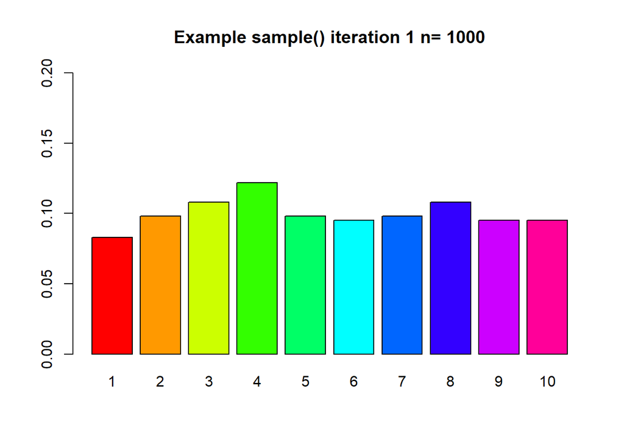

```r
mysample(n = 1000, iter = 1, time = 1)
```

Every second, a new bar plot relating to a sample is printed to the console, until samples have been taken. I just took one sample for the example so that 30 bar plots were not clogging up my knitted file.

# Task 5

- Use R to calculate:
  - $8 \choose 4$

```r
choose(8, 4)
```

```
## [1] 70
```

```r
1 - ppois(q = 3, lambda = 2)
```

```
## [1] 0.1428765
```

- Some more calculations in R
  - $P(y = 10), Y \sim NegBin(p = 0.4, r = 3)$

```r
choose(10 - 1, 3 - 1) * 0.4 ^ 3 * 0.6 ^ (10 - 3)
```

```
## [1] 0.06449725
```

```r
pbinom(q = 8, size = 15, prob = 0.4)
```

```
## [1] 0.9049526
```

# Task 6

I will put the myhyper() function in my package and run an example. The function is renamed to myhypergeometric() to avoid any naming errors in Lab 5, and to show that I am running it from my package.

```r
# Install package
devtools::install_local("C:/Users/Hunter/Desktop/Math4753Spring2023.zip")
# Ensure the package is installed correctly and recognized in Lab 5
library(Math4753Spring2023)
```

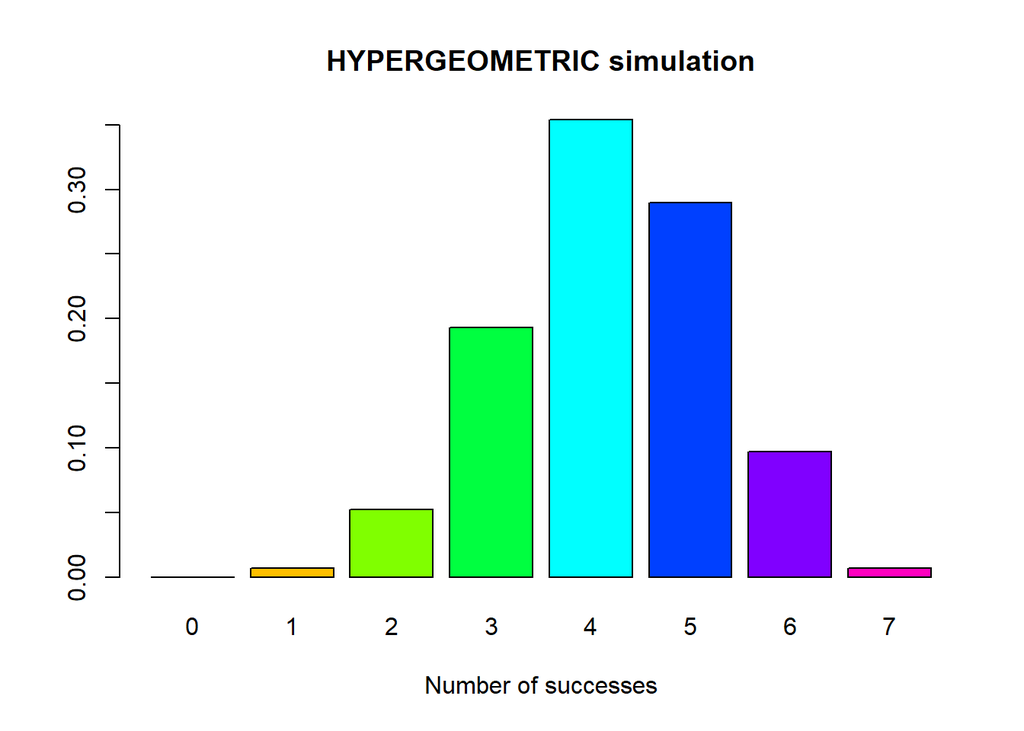

```
##
##     0     1     2     3     4     5     6     7
## 0.000 0.007 0.052 0.193 0.354 0.290 0.097 0.007
```

```r
# Run myhypergeometric() example
Math4753Spring2023::myhypergeometric(iter=1000, n=7, N=20, r=12)
```

```r
# CLEAN UP #################################################

# Clear environment
rm(list = ls())

# Clear packages
p_unload(all)  # Remove all add-ons
```

```
## The following packages have been unloaded:
## Math4753Spring2023, testthat, roxygen2, devtools, usethis, knitr, s20x, lattice, forcats, stringr, dplyr, purrr, readr, tidyr, tibble, ggplot2, tidyverse, pacman
```

```r
# Clear plots
dev.off()  # But only if there IS a plot
```

```r
# Clear console
cat("\014")  # ctrl+L
```

```r
# Clear mind :)
```